# Buisiness Intelligence Project

### Réalisé par :

```
Ayman Bouchareb
```

#### Objectif :

```
The Objectif of this Exercice is to create a model that predicts whether an patient will attend to his rendez-vous,
The (2) sets of data :
    Training Set (train.csv) : this file (set) will be used to train our model
    Testing Set (test.csv) : this file (set) will be used to benchmark our model
```

### 1- We prepare the IPython Envirement :

##### 1-0 we import relevent modules and functions for the data Manipulation :

```python
import warnings
warnings.filterwarnings('always')
```

```python
import pandas as pd
import numpy as np
import matplotlib.pyplot as plt
import sklearn as sk
import seaborn as sns
import scipy as sc
import statistics as ststs
import optuna as opt
```

#### 1-1 we import modules and functions for the machine learning Part :

```python
from sklearn.model_selection import train_test_split, StratifiedKFold,  cross_val_score, GridSearchCV, RandomizedSearchCV
from sklearn.neighbors import KNeighborsClassifier
from sklearn.tree import DecisionTreeClassifier
from sklearn.svm import SVC
from sklearn.metrics import accuracy_score, confusion_matrix, classification_report
from sklearn import metrics
from sklearn.ensemble import VotingClassifier
from sklearn.preprocessing import LabelEncoder
from datetime import datetime as date
```

#### 1-2 We write Some helper Functions :

```python
def extract_value_space_of_attribute(dataframe, filter):
    field_space_map = dict([(attribute, set([record[attribute] for (_,record) in dataframe.iterrows()])) for attribute in dataframe if filter(attribute)])
    return pd.DataFrame.from_dict(field_space_map, orient="index")
def transform_label_to_num(df, atts):
    enc = LabelEncoder()
    for att in atts:
        enc.fit(df[att])
        df[att] = enc.transform(df[att])
    return df
def Extract_Outiliers(df, features):
    return (df[((df[features] != 0) & (df[features] != 1)).sum(axis=1) == 0], df[((df[features] != 1) & (df[features] != 0)).sum(axis=1) != 0])
```

#### 1-3 we open the csv files :

```python
col_names =   ['patient_id', 'appointment_id','gender','schedule_day','appointment_day','age','neighborhood',
               'scholarship','hypertension','diabetes','alcoholism','handicap', 'sms_received','no_show']
paths = ["test.csv", "train.csv"]
train = pd.read_csv(paths[1], names=col_names, header=1)
test  = pd.read_csv(paths[0], names=col_names, header=1)
# we fuse the two datasets to have a single one named "dataset"
dataset = pd.concat([train, test], axis=0)
dataset['patient_id'] = dataset['patient_id'].astype('int64')
dataset['schedule_day']= pd.to_datetime(dataset['schedule_day'])
dataset['appointment_day']= pd.to_datetime(dataset['appointment_day'])
```

#### 1-4 we print the top 10 record in the dataset dataframe :

```python
dataset.head(10)
```

|  | patient_id | appointment_id | gender | schedule_day | appointment_day | age | neighborhood | scholarship | hypertension | diabetes | alcoholism | handicap | sms_received | no_show |
| --- | --- | --- | --- | --- | --- | --- | --- | --- | --- | --- | --- | --- | --- | --- |
| 0 | 558997776694438 | 5642503 | M | 2016-04-29 16:08:27+00:00 | 2016-04-29 00:00:00+00:00 | 56 | JARDIM DA PENHA | 0 | 0 | 0 | 0 | 0 | 0 | No |
| 1 | 4262962299951 | 5642549 | F | 2016-04-29 16:19:04+00:00 | 2016-04-29 00:00:00+00:00 | 62 | MATA DA PRAIA | 0 | 0 | 0 | 0 | 0 | 0 | No |
| 2 | 867951213174 | 5642828 | F | 2016-04-29 17:29:31+00:00 | 2016-04-29 00:00:00+00:00 | 8 | PONTAL DE CAMBURI | 0 | 0 | 0 | 0 | 0 | 0 | No |
| 3 | 8841186448183 | 5642494 | F | 2016-04-29 16:07:23+00:00 | 2016-04-29 00:00:00+00:00 | 56 | JARDIM DA PENHA | 0 | 1 | 1 | 0 | 0 | 0 | No |
| 4 | 95985133231274 | 5626772 | F | 2016-04-27 08:36:51+00:00 | 2016-04-29 00:00:00+00:00 | 76 | REPÚBLICA | 0 | 1 | 0 | 0 | 0 | 0 | No |
| 5 | 733688164476661 | 5630279 | F | 2016-04-27 15:05:12+00:00 | 2016-04-29 00:00:00+00:00 | 23 | GOIABEIRAS | 0 | 0 | 0 | 0 | 0 | 0 | Yes |
| 6 | 3449833394123 | 5630575 | F | 2016-04-27 15:39:58+00:00 | 2016-04-29 00:00:00+00:00 | 39 | GOIABEIRAS | 0 | 0 | 0 | 0 | 0 | 0 | Yes |
| 7 | 56394729949972 | 5638447 | F | 2016-04-29 08:02:16+00:00 | 2016-04-29 00:00:00+00:00 | 21 | ANDORINHAS | 0 | 0 | 0 | 0 | 0 | 0 | No |
| 8 | 78124564369297 | 5629123 | F | 2016-04-27 12:48:25+00:00 | 2016-04-29 00:00:00+00:00 | 19 | CONQUISTA | 0 | 0 | 0 | 0 | 0 | 0 | No |
| 9 | 734536231958495 | 5630213 | F | 2016-04-27 14:58:11+00:00 | 2016-04-29 00:00:00+00:00 | 30 | NOVA PALESTINA | 0 | 0 | 0 | 0 | 0 | 0 | No |

##### 1-5 we extract metadata about the dataset :

##### 1-5-1 we print the volume of the dataset, and the dimensions count :

```python
recordsCount, dimsCount = dataset.shape
pd.DataFrame([["Dataset Set",recordsCount, dimsCount]], columns=["","Records Count", "Dimensions Count"])
```

|  |  | Records Count | Dimensions Count |
| --- | --- | --- | --- |
| 0 | Dataset Set | 110524 | 14 |

##### 1-5-2 we extract the types of the attributes :

```python
cat_portion = dataset.select_dtypes(include=['object'])
print('Number of categorical variables : ',len(cat_portion.columns))

num_portion = dataset.select_dtypes(include=['int64'])
print('Number of numerical variables : ',len(num_portion.columns))

dataset.dtypes
```

```
Number of categorical variables :  3
Number of numerical variables :  9
```

```
patient_id                       int64
appointment_id                   int64
gender                          object
schedule_day       datetime64[ns, UTC]
appointment_day    datetime64[ns, UTC]
age                              int64
neighborhood                    object
scholarship                      int64
hypertension                     int64
diabetes                         int64
alcoholism                       int64
handicap                         int64
sms_received                     int64
no_show                         object
dtype: object
```

##### 1-5-3 We extract Data descriptions :

```
1-5-3-1 Numerical data table :
```

```python
dataset.describe()
```

|  | patient_id | appointment_id | age | scholarship | hypertension | diabetes | alcoholism | handicap | sms_received |
| --- | --- | --- | --- | --- | --- | --- | --- | --- | --- |
| count | 1.105240e+05 | 1.105240e+05 | 110524.000000 | 110524.000000 | 110524.000000 | 110524.000000 | 110524.000000 | 110524.000000 | 110524.000000 |
| mean | 1.475000e+14 | 5.675304e+06 | 37.089275 | 0.098268 | 0.197242 | 0.071867 | 0.030401 | 0.022249 | 0.321034 |
| std | 2.560974e+14 | 7.129547e+04 | 23.109929 | 0.297678 | 0.397919 | 0.258268 | 0.171688 | 0.161545 | 0.466876 |
| min | 3.921700e+04 | 5.030230e+06 | -1.000000 | 0.000000 | 0.000000 | 0.000000 | 0.000000 | 0.000000 | 0.000000 |
| 25% | 4.172929e+12 | 5.640285e+06 | 18.000000 | 0.000000 | 0.000000 | 0.000000 | 0.000000 | 0.000000 | 0.000000 |
| 50% | 3.173700e+13 | 5.680572e+06 | 37.000000 | 0.000000 | 0.000000 | 0.000000 | 0.000000 | 0.000000 | 0.000000 |
| 75% | 9.439381e+13 | 5.725522e+06 | 55.000000 | 0.000000 | 0.000000 | 0.000000 | 0.000000 | 0.000000 | 1.000000 |
| max | 9.999816e+14 | 5.790484e+06 | 115.000000 | 1.000000 | 1.000000 | 1.000000 | 1.000000 | 4.000000 | 1.000000 |

```
1-5-3-2 Descriptive Data Statistics :
```

```python
def categorical_description(df):
    return pd.DataFrame.from_dict({attribute:(df[attribute].nunique(), df[attribute].mode()[0]) for attribute in df if attribute in cat_portion}, orient='index', columns=['Unique Values Count', 'Most frequent Value'])
categorical_description(dataset)
```

|  | Unique Values Count | Most frequent Value |
| --- | --- | --- |
| gender | 2 | F |
| neighborhood | 81 | JARDIM CAMBURI |
| no_show | 2 | No |

##### 1-5-4 Visualizing Data :

```
Chart of gender with regards to no_show attribute
```

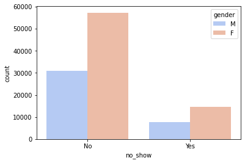

```python
for i, col in enumerate(cat_portion):
    if col != "neighborhood" and col != "no_show":
        print(f"Chart of {col} with regards to no_show attribute")
        plt.figure(i)
        sns.countplot(x = cat_portion['no_show'], palette='coolwarm', hue=col, data=cat_portion)
        plt.show()
```

[output not shown]

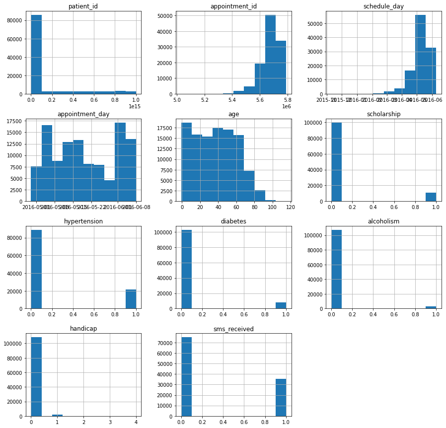

```python
print("chart of attributes with regards tono_show attribute")
dataset.hist(figsize=(15,15))
plt.show()
```

[output not shown]

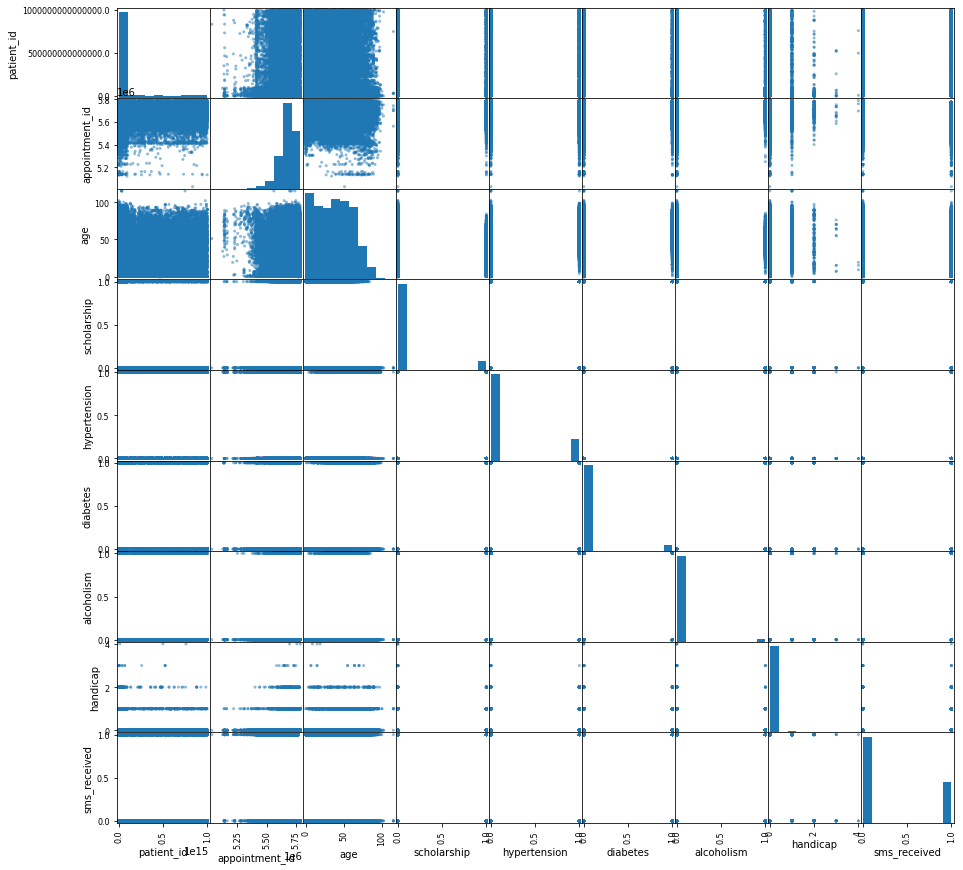

```python
print("scatter matrix of attributes with regards tono_show attribute")
pd.plotting.scatter_matrix(dataset, figsize=(15,15))
plt.show()
```

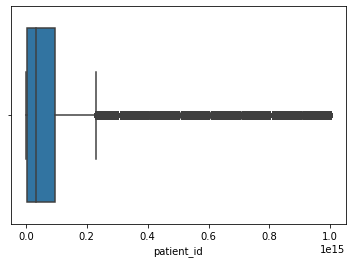

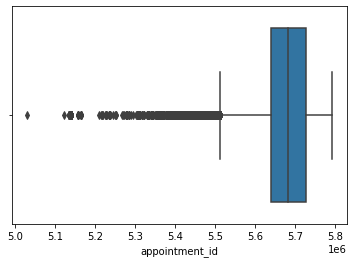

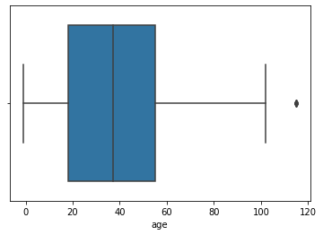

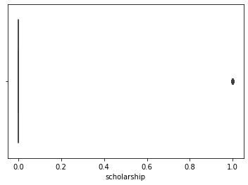

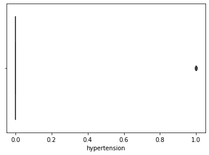

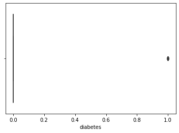

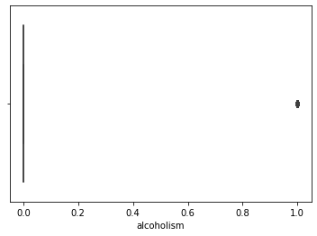

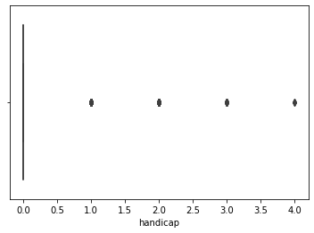

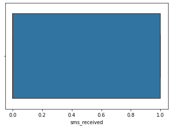

```python
num_dataset = dataset[[att for att in dataset if att in num_portion.columns]]
for i, col in enumerate(num_dataset):
    plt.figure(i)
    sns.boxplot(x=dataset[col])
```

#### 1-6 Data cleaning :

```
1-6-1 Cleansing of Missing Data
```

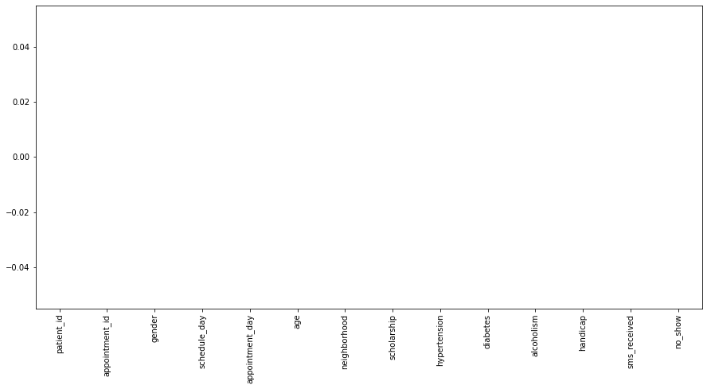

```python
dataset.isnull().sum().plot(kind='bar', figsize=(15,7))
```

from the chart we can conclude that no data is parsed wrongly or is marked missing in the preparsing phase

```
1-6-2 Fixing Outlier Data :
```

```python
dataset[dataset["age"] <= 0]
```

|  | patient_id | appointment_id | gender | schedule_day | appointment_day | age | neighborhood | scholarship | hypertension | diabetes | alcoholism | handicap | sms_received | no_show |
| --- | --- | --- | --- | --- | --- | --- | --- | --- | --- | --- | --- | --- | --- | --- |
| 58 | 71844284745331 | 5638545 | F | 2016-04-29 08:08:43+00:00 | 2016-04-29 00:00:00+00:00 | 0 | CONQUISTA | 0 | 0 | 0 | 0 | 0 | 0 | No |
| 62 | 236623344873175 | 5628286 | M | 2016-04-27 10:46:12+00:00 | 2016-04-29 00:00:00+00:00 | 0 | SÃO BENEDITO | 0 | 0 | 0 | 0 | 0 | 0 | No |
| 63 | 188517384712787 | 5616082 | M | 2016-04-25 13:28:21+00:00 | 2016-04-29 00:00:00+00:00 | 0 | ILHA DAS CAIEIRAS | 0 | 0 | 0 | 0 | 0 | 1 | No |
| 64 | 271881817799985 | 5628321 | M | 2016-04-27 10:48:50+00:00 | 2016-04-29 00:00:00+00:00 | 0 | CONQUISTA | 0 | 0 | 0 | 0 | 0 | 0 | No |
| 66 | 86471282513499 | 5639264 | F | 2016-04-29 08:53:02+00:00 | 2016-04-29 00:00:00+00:00 | 0 | NOVA PALESTINA | 0 | 0 | 0 | 0 | 0 | 0 | No |
| ... | ... | ... | ... | ... | ... | ... | ... | ... | ... | ... | ... | ... | ... | ... |
| 20344 | 147395196662956 | 5702537 | F | 2016-05-16 12:30:58+00:00 | 2016-06-01 00:00:00+00:00 | 0 | RESISTÊNCIA | 0 | 0 | 0 | 0 | 0 | 0 | No |
| 20345 | 5577525313231 | 5777724 | M | 2016-06-06 14:22:34+00:00 | 2016-06-08 00:00:00+00:00 | 0 | RESISTÊNCIA | 0 | 0 | 0 | 0 | 0 | 0 | No |
| 20453 | 614245995575 | 5772400 | F | 2016-06-03 15:18:44+00:00 | 2016-06-03 00:00:00+00:00 | 0 | RESISTÊNCIA | 0 | 0 | 0 | 0 | 0 | 0 | No |
| 20459 | 43218463343323 | 5769545 | F | 2016-06-03 08:56:51+00:00 | 2016-06-03 00:00:00+00:00 | 0 | RESISTÊNCIA | 0 | 0 | 0 | 0 | 0 | 0 | No |
| 20506 | 476946211846992 | 5786918 | F | 2016-06-08 09:04:18+00:00 | 2016-06-08 00:00:00+00:00 | 0 | MARIA ORTIZ | 0 | 0 | 0 | 0 | 0 | 0 | No |

3540 rows × 14 columns

```python
dataset, outliers = Extract_Outiliers(dataset, ['hypertension', 'diabetes', 'alcoholism', 'handicap'])
pd.DataFrame.from_dict({"Dataset Precleanup":[dataset.size + outliers.size,  outliers.size],"Dataset Postcleanup": [dataset.size, 0]}, orient='index', columns=['dataset size', 'Outliers Size'])
```

|  | dataset size | Outliers Size |
| --- | --- | --- |
| Dataset Precleanup | 1547336 | 2786 |
| Dataset Postcleanup | 1544550 | 0 |

```
array([<AxesSubplot:>], dtype=object)
```

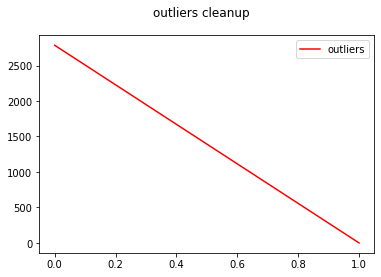

[figure not shown]

```python
pd.DataFrame.from_dict({"outliers":     [outliers.size,  0]}).plot(title="outliers cleanup", subplots=True, color="red")
pd.DataFrame.from_dict({"dataset rows" : [dataset.size + outliers.size, dataset.size]}).plot(title="dataset cleanup", subplots=True)
```

```python
dataset = dataset[dataset['age']      >= 1] ## we filter the data with age <= 0 out
```

```python
dataset[['schedule_day','appointment_day']] = dataset[['appointment_day','schedule_day']].where(dataset['schedule_day'] > dataset['appointment_day'], dataset[['schedule_day','appointment_day']].values)
```

```python
dataset.describe()
```

|  | patient_id | appointment_id | age | scholarship | hypertension | diabetes | alcoholism | handicap | sms_received |
| --- | --- | --- | --- | --- | --- | --- | --- | --- | --- |
| count | 1.067850e+05 | 1.067850e+05 | 106785.000000 | 106785.000000 | 106785.000000 | 106785.00000 | 106785.000000 | 106785.000000 | 106785.000000 |
| mean | 1.473169e+14 | 5.675426e+06 | 38.299742 | 0.101054 | 0.203353 | 0.07398 | 0.031390 | 0.019113 | 0.323435 |
| std | 2.558748e+14 | 7.133603e+04 | 22.452916 | 0.301401 | 0.402494 | 0.26174 | 0.174371 | 0.136923 | 0.467789 |
| min | 3.921700e+04 | 5.030230e+06 | 1.000000 | 0.000000 | 0.000000 | 0.00000 | 0.000000 | 0.000000 | 0.000000 |
| 25% | 4.175888e+12 | 5.640483e+06 | 19.000000 | 0.000000 | 0.000000 | 0.00000 | 0.000000 | 0.000000 | 0.000000 |
| 50% | 3.174215e+13 | 5.680740e+06 | 38.000000 | 0.000000 | 0.000000 | 0.00000 | 0.000000 | 0.000000 | 0.000000 |
| 75% | 9.433654e+13 | 5.725625e+06 | 56.000000 | 0.000000 | 0.000000 | 0.00000 | 0.000000 | 0.000000 | 1.000000 |
| max | 9.999816e+14 | 5.790484e+06 | 115.000000 | 1.000000 | 1.000000 | 1.00000 | 1.000000 | 1.000000 | 1.000000 |

#### 1-7 Transforming Data:

```
1-7-1 Proposing New fields :
```

since it's hard to work with datetime as a field in the model making we propose creating a new field called delay (oppointment_day - schedule_day), and also add a field for the day of the week of the appointment

```python
dataset['time_gap'] = (dataset['appointment_day'] - dataset['schedule_day']).apply(lambda x : x.total_seconds())
day_of_week = {day:i for i, day in enumerate(["Monday", "Tuesday", "Wednesday", "Thursday", "Friday", "Saturday", "Sunday"])}
dataset['appointment_day'] = dataset['appointment_day'].apply(lambda x : day_of_week[x.strftime("%A")])
dataset['schedule_day'] = dataset['schedule_day'].apply(lambda x : day_of_week[x.strftime("%A")])
dataset['age'] = dataset['age'].apply(lambda x : 1 if x < 18 else 2 if x < 35 else 3 if x < 60 else 4)
```

for the fields to be dropped we chose the IDs since they are systemic for identifying records but useless when it comes to influencing the "no_show" field

```python
dataset.drop(columns=['patient_id', 'appointment_id' ], inplace=True)
```

```
1-7-2 Encoding Categorical Value into Numerical Values :
```

```python
dataset = transform_label_to_num(dataset, cat_portion.columns)
dataset.head(1000)
```

|  | gender | schedule_day | appointment_day | age | neighborhood | scholarship | hypertension | diabetes | alcoholism | handicap | sms_received | no_show | time_gap |
| --- | --- | --- | --- | --- | --- | --- | --- | --- | --- | --- | --- | --- | --- |
| 0 | 1 | 4 | 4 | 3 | 39 | 0 | 0 | 0 | 0 | 0 | 0 | 0 | 58107.0 |
| 1 | 0 | 4 | 4 | 4 | 45 | 0 | 0 | 0 | 0 | 0 | 0 | 0 | 58744.0 |
| 2 | 0 | 4 | 4 | 1 | 54 | 0 | 0 | 0 | 0 | 0 | 0 | 0 | 62971.0 |
| 3 | 0 | 4 | 4 | 3 | 39 | 0 | 1 | 1 | 0 | 0 | 0 | 0 | 58043.0 |
| 4 | 0 | 2 | 4 | 4 | 58 | 0 | 1 | 0 | 0 | 0 | 0 | 0 | 141789.0 |
| ... | ... | ... | ... | ... | ... | ... | ... | ... | ... | ... | ... | ... | ... |
| 1033 | 0 | 4 | 4 | 3 | 10 | 0 | 0 | 0 | 0 | 0 | 0 | 0 | 35127.0 |
| 1034 | 1 | 0 | 4 | 3 | 10 | 0 | 1 | 0 | 0 | 0 | 1 | 1 | 921702.0 |
| 1035 | 1 | 4 | 4 | 4 | 10 | 0 | 0 | 0 | 0 | 0 | 0 | 0 | 34005.0 |
| 1036 | 1 | 0 | 4 | 3 | 10 | 0 | 1 | 0 | 0 | 0 | 1 | 1 | 921447.0 |
| 1037 | 1 | 4 | 4 | 1 | 17 | 0 | 0 | 0 | 0 | 0 | 0 | 0 | 34938.0 |

1000 rows × 13 columns

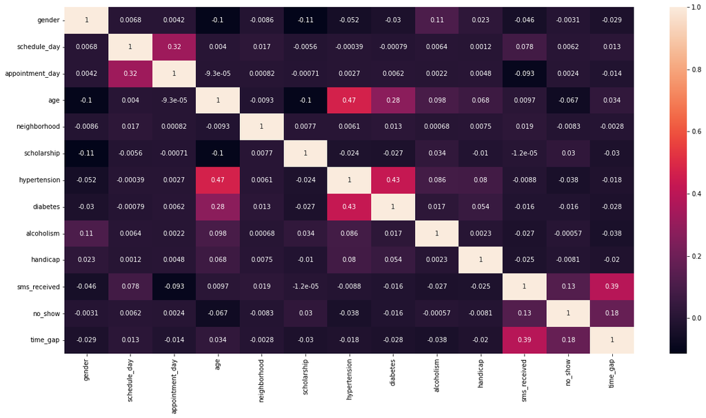

```python
plt.figure(figsize=(20,10))
sns.heatmap(dataset.corr(), annot=True)
plt.show()
```

##### 1-8 Model Building :

```
1-8-1 We split Data into 2 sets :
```

```python
## Diviser l’ensemble des données « dataset » en deux sous-ensembles : 80% pour l’apprentissage (training data set) et 20% pour le test (test data set)
training_set, testing_set = train_test_split(dataset, test_size = 0.2)
## Diviser le sous-ensemble d’apprentissage (training data Set) en deux sous-ensembles : 75% pour l’apprentissage et 25% pour la validation.
training_set, validation_set = train_test_split(training_set, test_size = 0.25)
print(f'Train Shape : {train.shape} , Test Shape : {test.shape}')
print(f'testing_set percent : {testing_set.size / dataset.size} , training_set percent : {training_set.size / dataset.size}, , validation_set percent : {validation_set.size / dataset.size}')
```

```
Train Shape : (89998, 14) , Test Shape : (20526, 14)
testing_set percent : 0.2 , training_set percent : 0.6, , validation_set percent : 0.2
```

```python
features, goal= dataset.columns, 'no_show'
features.drop(goal)
xtrain, ytrain = training_set[features].drop([goal], axis=1), training_set[goal]
xtest, ytest = validation_set[features].drop([goal], axis=1), validation_set[goal]
```

```
1-8-2 Training the Models :
```

```python
kfold = StratifiedKFold(n_splits=10)
random_state = 2
classifiers = [ ("KNeighborsClassifier", KNeighborsClassifier()),
                ("DecisionTreeClassifier", DecisionTreeClassifier(random_state=random_state))]

cv_results = []
for _, classifier in classifiers :
    cv_results.append(cross_val_score(classifier, xtrain, y = ytrain, scoring = "accuracy", cv = kfold, n_jobs=4))
cv_means = []
cv_std = []
for cv_result in cv_results:
    cv_means.append(cv_result.mean())
    cv_std.append(cv_result.std())

cv_res = pd.DataFrame({"CrossValMeans":cv_means,"CrossValerrors": cv_std,"Algorithm":["KNeighbors", "DecisionTree"]})
```

```python
cv_res
```

|  | CrossValMeans | CrossValerrors | Algorithm |
| --- | --- | --- | --- |
| 0 | 0.767102 | 0.002449 | KNeighbors |
| 1 | 0.723073 | 0.005735 | DecisionTree |

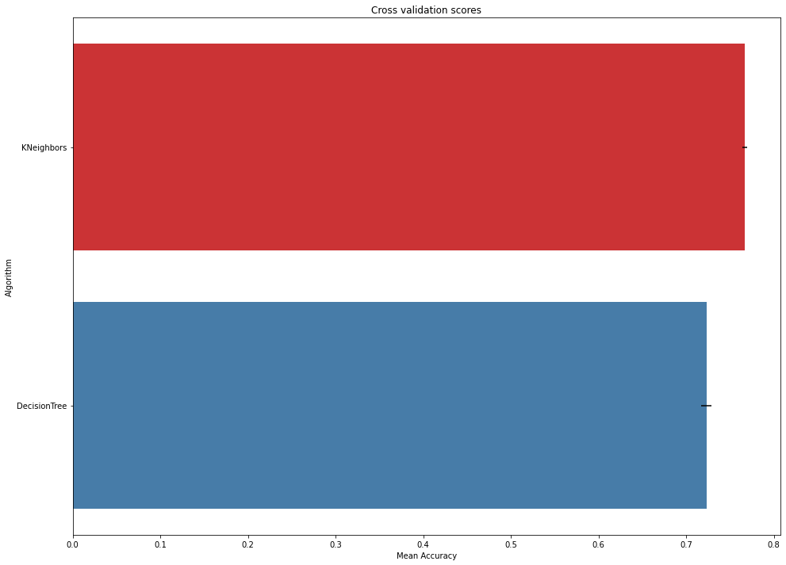

```python
plt.figure(figsize=(16,12))
g = sns.barplot(x ="CrossValMeans",y ="Algorithm",data = cv_res, palette="Set1",orient = "h",**{'xerr':cv_std})
g.set_xlabel("Mean Accuracy")
g = g.set_title("Cross validation scores")
plt.show()
```

```
1-8-3 Fine Tuning Parameters of Classifiers :
```

```python
parameters = {
    "KNeighborsClassifier" :  {
      'n_neighbors': [1,30],
      'leaf_size': [1,100,1000],
      'weights' : ['uniform', 'distance'],
      'metric': ('minkowski', 'chebyshev', 'euclidean'),
    },
    "DecisionTreeClassifier" : {
        'criterion': ['gini', 'entropy'],
        'max_depth': [2,4,6,8,10],
        'max_features': [0.1, 0.2, 0.3, 0.4, 0.5],
        'min_samples_split': [2,3,4,5,6,7]
    }
}
```

```python
fune_tuned_classifiers = {}
for name, classifier in classifiers :
    gridsrch = GridSearchCV(classifier,param_grid = parameters[name], cv=kfold, scoring="accuracy", n_jobs=4, verbose = 1)
    gridsrch.fit(xtrain,ytrain)
    fune_tuned_classifiers[name] = gridsrch.best_estimator_
```

```
Fitting 10 folds for each of 36 candidates, totalling 360 fits
Fitting 10 folds for each of 300 candidates, totalling 3000 fits
```

```
1-8-4 We generate multiple training/validation sets for each model :
```

```python
gen_samples =  lambda n : [training_set.sample(frac = 0.01) for _ in range(n)]
```

[output not shown]

```python
samples, results = gen_samples(50), {}
for name in fune_tuned_classifiers:
    classifier = fune_tuned_classifiers[name]
    acc_datas = []
    for sample in samples:
        x, y = sample[features].drop([goal], axis=1), sample[goal]
        classifier.fit(x, y)
        predictions = classifier.predict(xtest)
        acc_datas.append(([accuracy_score(ytest,predictions), classifier]))
    results[name] = acc_datas
```

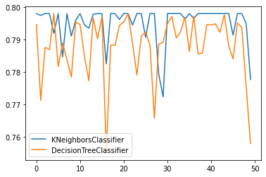

```python
formated_results = pd.DataFrame.from_dict({key:[value[0] for value in results[key]] for key in results})
formated_results.plot()
```

```python
formated_results = pd.DataFrame({key :ststs.mean([value for [value, _] in results[key]]) for key in results}, index=['Mean_Score'])
formated_results.T
```

|  | Mean_Score |
| --- | --- |
| KNeighborsClassifier | 0.795183 |
| DecisionTreeClassifier | 0.788113 |

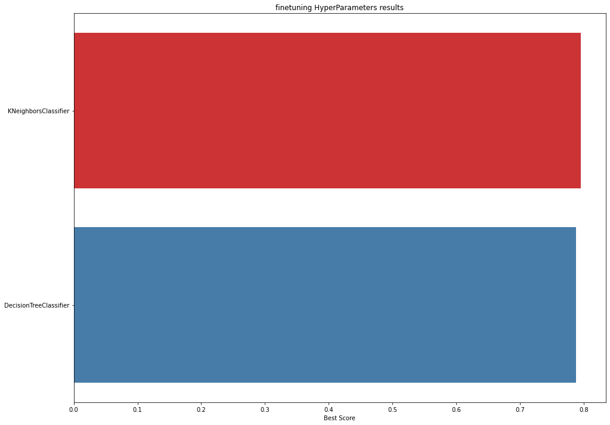

```python
plt.figure(figsize=(16,12))
g = sns.barplot(data = formated_results, palette="Set1",orient = "h")
g.set_xlabel("Best Score")
g = g.set_title("finetuning HyperParameters results")
plt.show()
```

#### 1-9 Test of the model :

```python
Accuracies = []
for name in results :
    classifier = results[name][1][1]
    predictions = classifier.predict(xtest)
    Accuracies.append((name, [accuracy_score(ytest,predictions), classifier]))
name, [_, Chosen] = sorted(Accuracies, key=lambda x: x[0])[1]
print("The Model Chosen based on accuracy is ", name)
```

```
The Model Chosen based on accuracy is  KNeighborsClassifier
```

```python
pd.DataFrame.from_dict(dict(Accuracies))
```

|  | KNeighborsClassifier | DecisionTreeClassifier |
| --- | --- | --- |
| 0 | 0.777684 | 0.757878 |
| 1 | KNeighborsClassifier(leaf_size=100, metric='ch... | DecisionTreeClassifier(criterion='entropy', ma... |

```python
Y = testing_set.no_show
X = testing_set.drop(['no_show'], axis=1)
```

```python
predictions = Chosen.predict(X)
```

```python
print(name, "classification_report")
print(classification_report(Y, predictions))
```

```
KNeighborsClassifier classification_report
              precision    recall  f1-score   support

           0       0.81      0.95      0.87     17086
           1       0.33      0.11      0.16      4271

    accuracy                           0.78     21357
   macro avg       0.57      0.53      0.52     21357
weighted avg       0.71      0.78      0.73     21357
```

```python
cfmatrix = confusion_matrix(Y, predictions)
print("confusion matrix of the predictions\n", cfmatrix)
```

```
confusion matrix of the predictions
 [[16167   919]
 [ 3822   449]]
```

```python
accscore = accuracy_score(Y, predictions)
print("accuracy score of the predictions", accscore)
```

```
accuracy score of the predictions 0.7780118930561408
```